# Assignment 5

Rishi Vishal Garlapati (ID: GR018649)

2022-09-27

## Installing Packages

install.packages(“tidyverse”)

install.packages(“dplyr”)

install.packages(“dslabs”)

## Loading Libraries

```r
library(tidyverse)
library(dplyr)
```

```r
library(dslabs)
```

## Checking Dataset Sample

```r
df <- gapminder

knitr::kable(df %>% head(10), caption = "Table: Gapminder dataset (Sample)")
```

Table: Gapminder dataset (Sample)

| country | year | infant_mortality | life_expectancy | fertility | population | gdp | continent | region |
| --- | --- | --- | --- | --- | --- | --- | --- | --- |
| Albania | 1960 | 115.40 | 62.87 | 6.19 | 1636054 | NA | Europe | Southern Europe |
| Algeria | 1960 | 148.20 | 47.50 | 7.65 | 11124892 | 13828152297 | Africa | Northern Africa |
| Angola | 1960 | 208.00 | 35.98 | 7.32 | 5270844 | NA | Africa | Middle Africa |
| Antigua and Barbuda | 1960 | NA | 62.97 | 4.43 | 54681 | NA | Americas | Caribbean |
| Argentina | 1960 | 59.87 | 65.39 | 3.11 | 20619075 | 108322326649 | Americas | South America |
| Armenia | 1960 | NA | 66.86 | 4.55 | 1867396 | NA | Asia | Western Asia |
| Aruba | 1960 | NA | 65.66 | 4.82 | 54208 | NA | Americas | Caribbean |
| Australia | 1960 | 20.30 | 70.87 | 3.45 | 10292328 | 96677859364 | Oceania | Australia and New Zealand |
| Austria | 1960 | 37.30 | 68.75 | 2.70 | 7065525 | 52392699681 | Europe | Western Europe |
| Azerbaijan | 1960 | NA | 61.33 | 5.57 | 3897889 | NA | Asia | Western Asia |

## Examining life expectancy over time using a series of boxplots

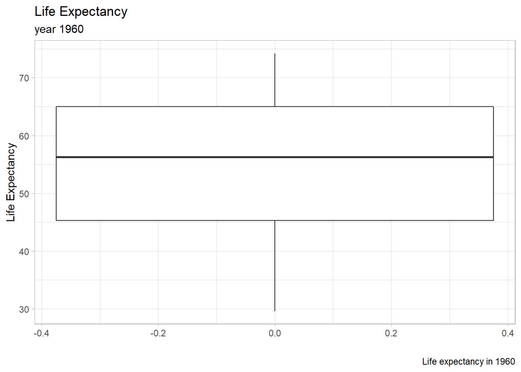

```r
df %>% filter(year == 1960) %>%
ggplot(aes(y=life_expectancy)) +
  geom_boxplot() +
  theme_light() +
  labs(title = "Life Expectancy",
       subtitle = "year 1960",
       caption= "Life expectancy in 1960",
       y = "Life Expectancy",
       x = "")
```

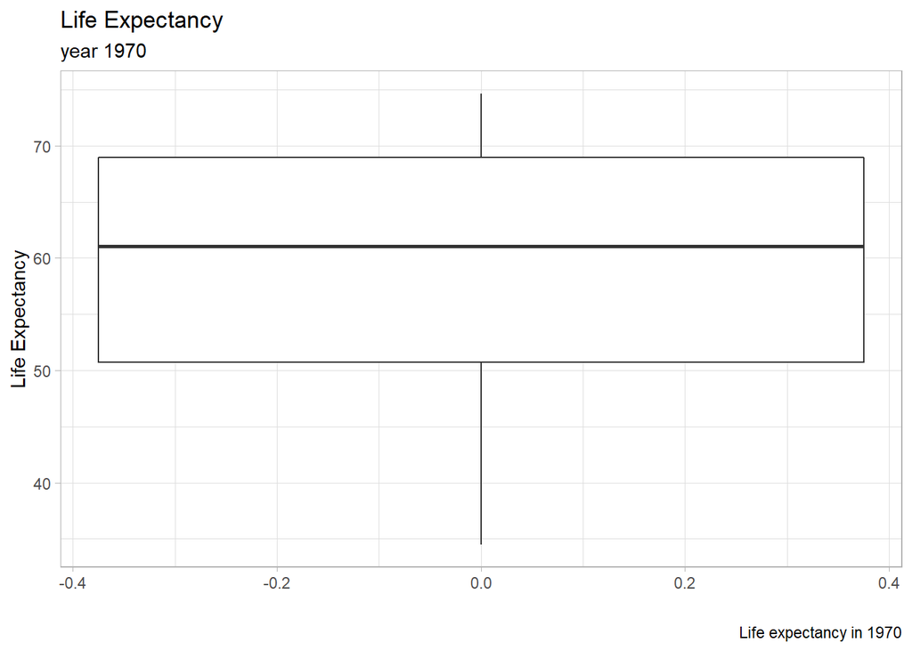

```r
df %>% filter(year == 1970) %>%
ggplot(aes(y=life_expectancy)) +
  geom_boxplot() +
  theme_light() +
  labs(title = "Life Expectancy",
       subtitle = "year 1970",
       caption= "Life expectancy in 1970",
       y = "Life Expectancy",
       x = "")
```

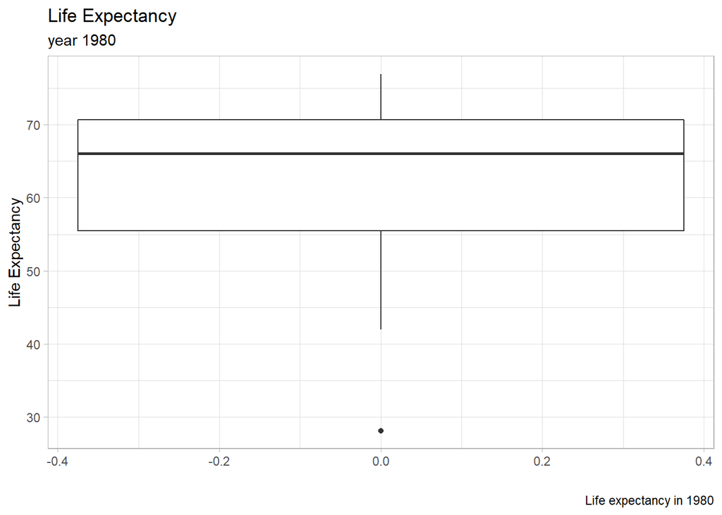

```r
df %>% filter(year == 1980) %>%
ggplot(aes(y=life_expectancy)) +
  geom_boxplot() +
  theme_light() +
  labs(title = "Life Expectancy",
       subtitle = "year 1980",
       caption= "Life expectancy in 1980",
       y = "Life Expectancy",
       x = "")
```

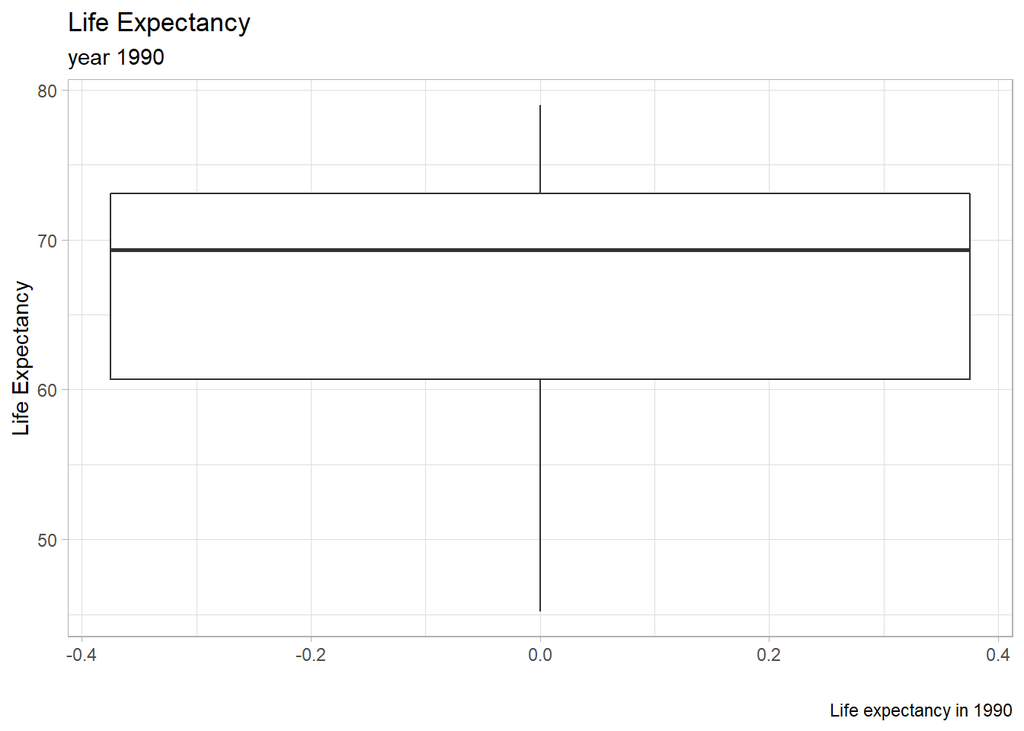

```r
df %>% filter(year == 1990) %>%
ggplot(aes(y=life_expectancy)) +
  geom_boxplot() +
  theme_light() +
  labs(title = "Life Expectancy",
       subtitle = "year 1990",
       caption= "Life expectancy in 1990",
       y = "Life Expectancy",
       x = "")
```

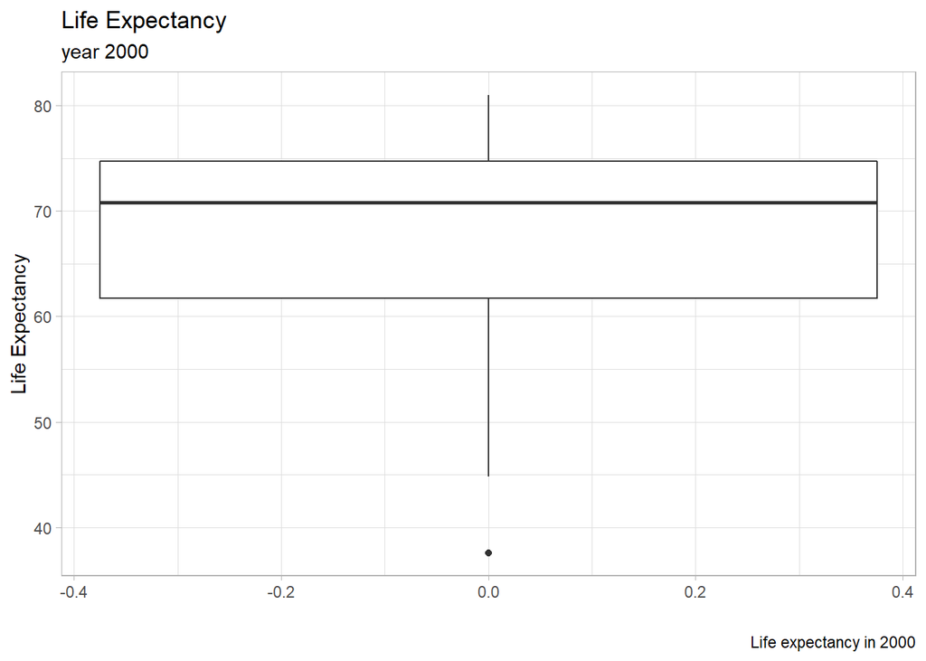

```r
df %>% filter(year == 2000) %>%
ggplot(aes(y=life_expectancy)) +
  geom_boxplot() +
  theme_light() +
  labs(title = "Life Expectancy",
       subtitle = "year 2000",
       caption= "Life expectancy in 2000",
       y = "Life Expectancy",
       x = "")
```

## Faceting boxplot by continent (e.g. for 1960)

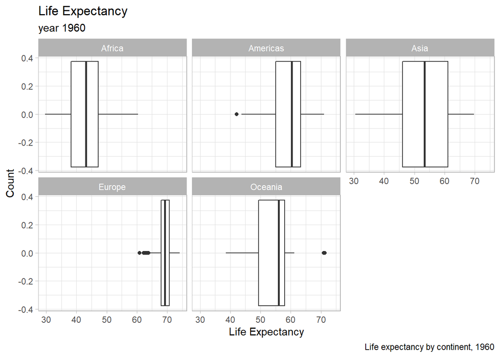

```r
df %>% filter(year == 1960) %>%
ggplot(aes(x=life_expectancy)) +
  geom_boxplot() +
  theme_light() +
  labs(title = "Life Expectancy",
       subtitle = "year 1960",
       caption = "Life expectancy by continent, 1960",
       y = "Count",
       x = "Life Expectancy") +
  facet_wrap(~ continent)
```

From the output, is is possible to facet the box plots by continent.

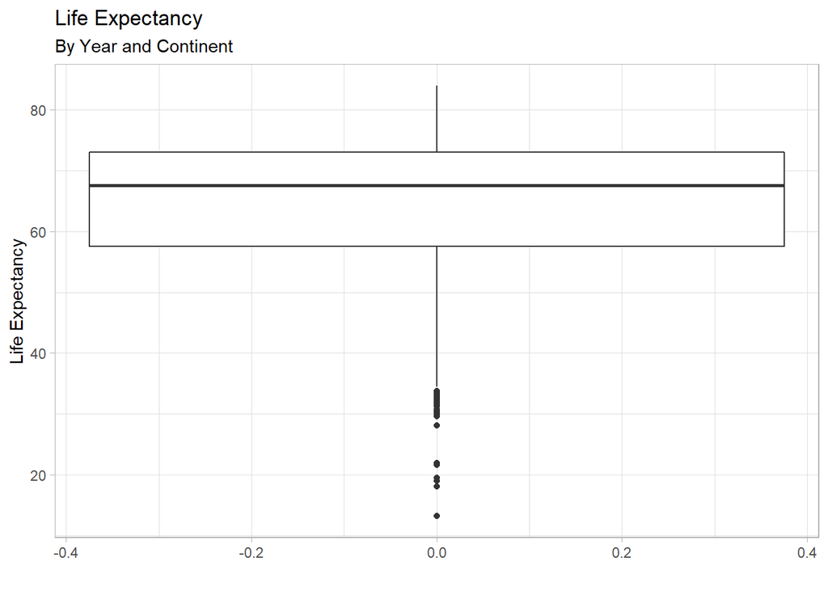

```r
# Group by year and continent
gapminder %>%
  group_by(year, continent) %>%
  #Creating Box Plot
  ggplot(aes(y=life_expectancy)) +
  geom_boxplot() +
  theme_light() +
  labs(title = "Life Expectancy",
       subtitle = "By Year and Continent",
       y = "Life Expectancy",
       x = "")
```

## Interpreting the boxplots

The black line in the middle of the box represents the median of the variable. The upper and lower edges of the box are the 1st and 3rd quartiles (the 25th and 75th percentiles), visually showing the range of 50% of the variable.

Boxplots also display two whiskers that extend from the upper and lower edges of the box to show the smallest and largest non-outlier data points, which represent where the first and last 25% of the data fall.

The upper whisker extends from the edge to the largest value no further than 1.5 * IQR from the edge. IQR is the inter-quartile range or distance between the first and third quartiles. The lower whisker extends from the edge to the smallest value at most, 1.5 * IQR of the hinge.